# Booze and Brews - Case Study

Joey Hernandez and Robert Blue

2022-10-18

## Introduction:

#### Thank you Mr. Smith, and Mr. Jones for the opportunity for us to deliver Beer and Brewery insights so that your company Booze and Brews can align it’s strategic plan for growth, and future offerings so that you can maximize revenues and grow your presence.

#### It was a pleasure working with you and your team, and we hope you are able to gain strong insights from our analysis of the data you provided us.

#### What you will find in this Analysis packet is our step by step process of investigation and analysis into the questions you had regarding the United States Brewery market. Below you will see a list of topics to be covered:

1. Initialization of Data and software libraries
2. Data at a glance and Missing Values
3. Question of Interest 1 - How many Breweries are in each State?
4. Question of Interest 2 - Describe the Merging of Beer and Breweries Data.
5. Question of Interest 3 - How are the missing values addressed?
6. Question of Interest 4 - Uncover the Median ABV, and IBU values for each State.
7. Question of Interest 5 - Which State has the Max (highest) ABV Value? IBU?
8. Question of Interest 6 - What are your findings on the statistics and distribution of ABV values?
9. Question of Interest 7 - Is there a relationship between bitterness of beer and its alcoholic content?
10. Question of Interest 8 - Investigate the difference with respect to IBU and ABV between IPAs and Ales.
11. Question of Interest 9 - Extra Insight!
12. Conclusion

## Initialization of Data and Software Libraries:

The first step in our process is to load the data and necessary libraries so that we can investigate the data with a full assortment of tools needed to present our findings base on the beer and breweries data.

```r
library(tidyverse)
```

```r
library(ggplot2)
library(janitor)
library(usmap)
library(caret)
library(e1071)
library(class)
library(knitr)
library(ggthemes)
beer_data <-read.csv("C:/Users/Joey/Desktop/DDS_Work/Unit - 8/Beers.csv")
brew_data <- read.csv("C:/Users/Joey/Desktop/DDS_Work/Unit - 8/Breweries.csv")
```

## Data at a glance & Missing Vaules:

#### During our initial consultation, you mentioned the data could contain some missing values as well as some potential errors. In order for us to present the most accurate findings, we took a series of steps to ensure that any errors or missing values were either addressed or corrected.

1. Identify the rows and columns of the data sets. This first glance allows us to understand what type of variables and variable types we are working with, additionally, we are able to understand the size of data that we have.
2. Viewing the data sets allowed us to identify similar columns within the 2 groups that we could use to merge the data. Merging the data together allows us to create a data frame that contains all we need in one location. We will not yet merge the data within this step but we do take action and rename any columns that may be of interest. What you will find if you look at the data is that we changed both data brewery identification columns to the title ‘Brewery_id’ so that we could merge the data with this as our bridge variable.
3. Before merging the data together we checked each dataset individually for missing values and broke them into explicit and implicit missing values.
4. We addressed Explicit Values (NAs) by investigating why there may have been explicitly missing values in the data. Upon further investigation we discovered that certain values are not always reported (or are required to be reported) by breweries. This varies from brewery to brewery but most often has to do with state and other governing matters. In the case of missing IBU values this also varies from location to location and can be attributed to different crafting methods in addition to simply not being required to report. We did not completely leave out this data, but instead left it as NA when applicable since it represented such a high amount of data.
5. The data did contain some Implicit values in the form of missing data. Upon further investigation we were able to either remedy the missing values by researching the product in question, or gain an understanding of why a value may not have been present so that we could understand how it would impact the remaining data (or if it impacted the remaining data).
6. There was instances of duplicate data which were attributed to incorrect brewery locations, or were attributed to repeated batches of an offering as well as different sizes of certain drinks. The remedy was addressed on a case by case basis, but in short the only data removed was data that was incorrect, such as the duplicate locations entered by spelling, or typo errors.
7. While not a big issue, the state abbreviations all contained some white space before the actual character of the string. This white space was removed to better utilize the variable.
8. Finally after all found errors were addressed, we merged the data into one piece.

```r
#################### Exploring Raw Data ###########################
# check rows and columns
# head(beer_data)
# head(brew_data)

# rename columns for merging
names(beer_data)[1] <- 'beer_name'
names(brew_data)[2] <- 'Brew_name'
names(brew_data)[1]<- 'Brewery_id'

# checking for missing values beer
# sapply(beer_data,function(x) sum(is.na(x))/nrow(beer_data)) # 2.5% missing values - ABV | 41.7% missing values in IBU
# sapply(beer_data,function(x) sum(x== ""))

# checking for missing values brew
# sapply(brew_data,function(x) sum(is.na(x))/nrow(brew_data))
# sapply(brew_data,function(x) sum(x== ""))

# addressing the missing values from beer
beer_data[854,'Style'] = "Scottish Ale"
beer_data[867, 'Style'] = 'Marzen'



# looking for duplicates in data
# brew_data %>% get_dupes(Brewery_id)
# brew_data %>% get_dupes(Brew_name)
# beer_data %>% get_dupes(beer_name)
# beer_data %>% get_dupes(Brewery_id)
# beer_data %>% get_dupes(Beer_ID)

# addresses the duplicates in brew_data
brew_data<- brew_data[-c(96,378,262,139),]

# addresses the duplicates in beer_data
beer <- beer_data[!duplicated(beer_data$beer_name),]
# beer %>% get_dupes(Brewery_id) # these duplicates are for various drinks from the same brew id
# beer %>% get_dupes(Beer_ID) # fixed
# beer %>% get_dupes(beer_name)

# gets rid of the white space before the State abb.
brew_data$State<-trimws(brew_data$State, "left")


# merging beer and brew_data - with an inner join
beer_brew <- merge(brew_data, beer, by ='Brewery_id')
```

## Question of Interest 1:

#### How many breweries are in each state?

In order to represent and visually display this data, we first had to ensure that any duplicated values that would throw off the count for each state were handled. Next we grouped the variables of the data into a filtered set that we could call on to create our plot, and finally we plotted a map of the United States the Numerical brewery representation over each state. This type of plot intuitively shows where and how the brewery locations are distributed across the United States. Below you will find this breakdown visual as well as a table of the result for a list of comparisons.

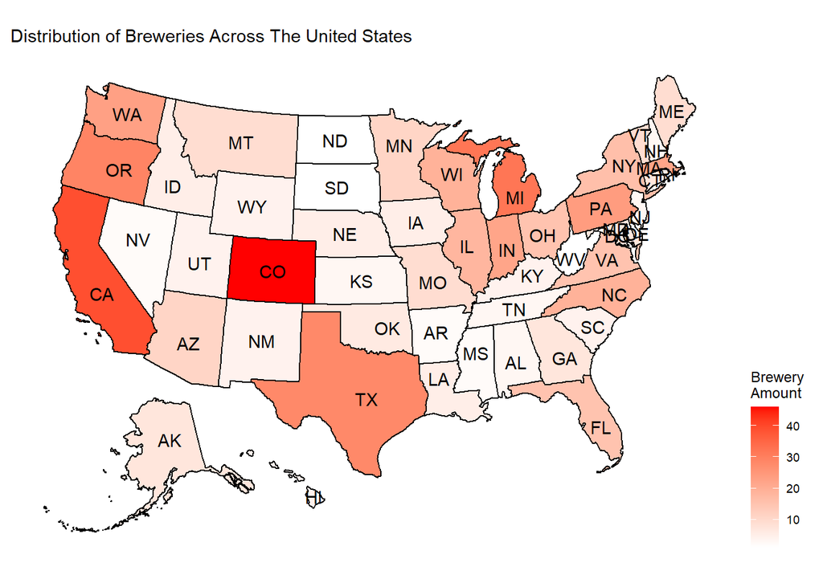

```r
################################### Question 1 ##################################

# this gets only one brewery name so that we don't have multiple brew representation because
# of the multiple drinks served by that one location.
state_num_data <- beer_brew[!duplicated(beer_brew$Brew_name),]

# the n_distinct takes care of the potential repeat brew representation making last line redundant
# but kept in as precautionary measure.
state_brew_plot <- state_num_data %>% group_by(State) %>%
  summarise(num_brew = n_distinct(Brew_name),
  mean_abv = mean(ABV), mean_ibu = mean(IBU)) %>%
  arrange(desc(num_brew))

# changes column State to state to satisfy the usmap argument
names(state_brew_plot)[1] <- 'state'

# makes into dataframe
state_brew_plot <- as.data.frame(state_brew_plot)

# plot of the Concentration of Breweries in the US
plot_usmap(data=state_brew_plot[,1:2],
           regions = "states",
           labels = TRUE,label_color = "black",
           values = "num_brew") +
          scale_fill_gradient(low = 'white', high = 'red')+
          labs(title = 'Distribution of Breweries Across The United States',
               fill = "Brewery \nAmount") +
          theme(legend.position = "right")
```

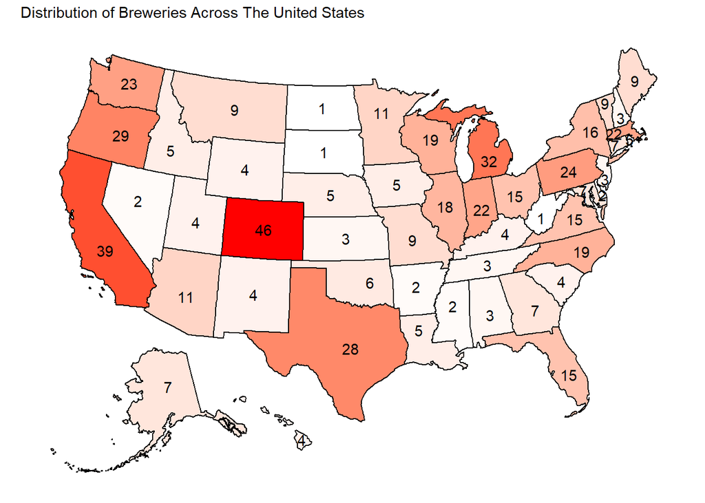

```r
# SECONDARY MAP TO DISPLAY ACTUAL REPRESENTAION OF NUMERICAL VALUE PER EACH STATE
# get centroids
centroid_labels <- usmapdata::centroid_labels("states")

names(centroid_labels)[4] <- 'state'

# join data to centroids (using lat/long as coord. for state centers on map plot)
data_labels <- merge(centroid_labels, state_brew_plot, by = "state")

# create US map with centroids and lat/long as the label
brews_per_state <- plot_usmap(data = state_brew_plot[,1:2],
                              values = "num_brew",
                              color = "black",
                              labels = F) +
  guides(fill = "none") +
  geom_text(data = data_labels,aes(x = x, y = y,
                                   label = scales::number(num_brew, accuracy = 1)),color = "black")+
  scale_fill_gradient(low = "white", high = "red") +
  labs(title = "Distribution of Breweries Across The United States",
       fill = "Brewery \nAmount") +
  theme(legend.position = "right")

brews_per_state
```

##### Please note that the table below contain a NaN value. This is because SD (South Dakota) only contains data for 1 brewery which did not report their IBU. When the data was filtered to remove Non-Value IBU data it kept SD because it still must be represented in this table to illustrate the Number of Breweries in each State.

```r
# table for display in RMD file
kable(state_num_data %>% group_by(State) %>%
summarise(Num_Brew = n_distinct(Brew_name),
          Mean_ABV = mean(na.omit(ABV)), Mean_IBU = mean(na.omit(IBU))) %>%
arrange(desc(Num_Brew)))
```

| State | Num_Brew | Mean_ABV | Mean_IBU |
| --- | --- | --- | --- |
| CO | 46 | 0.0617333 | 41.82759 |
| CA | 39 | 0.0599231 | 42.71429 |
| MI | 32 | 0.0571290 | 21.77778 |
| OR | 29 | 0.0568276 | 46.65000 |
| TX | 28 | 0.0586667 | 46.00000 |
| PA | 24 | 0.0597619 | 50.12500 |
| WA | 23 | 0.0584348 | 44.64286 |
| IN | 22 | 0.0608182 | 47.38462 |
| MA | 22 | 0.0575455 | 38.10000 |
| NC | 19 | 0.0574444 | 46.80000 |
| WI | 19 | 0.0522632 | 31.85714 |
| IL | 18 | 0.0581111 | 43.20000 |
| NY | 16 | 0.0528667 | 37.54545 |
| FL | 15 | 0.0569286 | 43.50000 |
| OH | 15 | 0.0661333 | 51.37500 |
| VA | 15 | 0.0593333 | 53.84615 |
| AZ | 11 | 0.0605000 | 35.40000 |
| MN | 11 | 0.0630909 | 60.25000 |
| ME | 9 | 0.0570000 | 66.25000 |
| MO | 9 | 0.0605556 | 48.20000 |
| MT | 9 | 0.0555000 | 48.75000 |
| VT | 9 | 0.0563333 | 32.60000 |
| AK | 7 | 0.0522857 | 36.60000 |
| CT | 7 | 0.0581429 | 51.50000 |
| GA | 7 | 0.0532857 | 38.00000 |
| MD | 7 | 0.0578571 | 52.50000 |
| OK | 6 | 0.0580000 | 20.00000 |
| IA | 5 | 0.0574000 | 39.33333 |
| ID | 5 | 0.0636000 | 38.75000 |
| LA | 5 | 0.0580000 | 34.33333 |
| NE | 5 | 0.0663333 | 11.00000 |
| RI | 5 | 0.0542000 | 23.00000 |
| HI | 4 | 0.0505000 | 22.50000 |
| KY | 4 | 0.0652500 | 44.50000 |
| NM | 4 | 0.0617500 | 15.00000 |
| SC | 4 | 0.0615000 | 17.50000 |
| UT | 4 | 0.0475000 | 34.00000 |
| WY | 4 | 0.0572500 | 16.33333 |
| AL | 3 | 0.0626667 | 53.00000 |
| KS | 3 | 0.0483333 | 28.66667 |
| NH | 3 | 0.0460000 | 15.00000 |
| NJ | 3 | 0.0510000 | 43.33333 |
| TN | 3 | 0.0500000 | 30.66667 |
| AR | 2 | 0.0485000 | 39.00000 |
| DE | 2 | 0.0550000 | 52.00000 |
| MS | 2 | 0.0575000 | 41.50000 |
| NV | 2 | 0.0500000 | 50.00000 |
| DC | 1 | 0.0500000 | 15.00000 |
| ND | 1 | 0.0500000 | 32.00000 |
| SD | 1 | 0.0550000 | NaN |
| WV | 1 | 0.0670000 | 71.00000 |

## Question of Interest 2:

#### Describe the Beer and Breweries Data Merging

Although the analysis of our data may use filtered version of the merged data set, below you will see a snippet of the beginning and ending our or merged data set.

```r
head(beer_brew)
```

```
  Brewery_id          Brew_name        City State     beer_name Beer_ID   ABV
1          1 NorthGate Brewing  Minneapolis    MN Maggie's Leap    2691 0.049
2          1 NorthGate Brewing  Minneapolis    MN    Wall's End    2690 0.048
3          1 NorthGate Brewing  Minneapolis    MN       Pumpion    2689 0.060
4          1 NorthGate Brewing  Minneapolis    MN   Parapet ESB    2687 0.056
5          1 NorthGate Brewing  Minneapolis    MN  Get Together    2692 0.045
6          1 NorthGate Brewing  Minneapolis    MN    Stronghold    2688 0.060
  IBU                               Style Ounces
1  26                  Milk / Sweet Stout     16
2  19                   English Brown Ale     16
3  38                         Pumpkin Ale     16
4  47 Extra Special / Strong Bitter (ESB)     16
5  50                        American IPA     16
6  25                     American Porter     16
```

```r
tail(beer_brew)
```

```
     Brewery_id                     Brew_name          City State
2296        556         Ukiah Brewing Company         Ukiah    CA
2297        557       Butternuts Beer and Ale Garrattsville    NY
2298        557       Butternuts Beer and Ale Garrattsville    NY
2299        557       Butternuts Beer and Ale Garrattsville    NY
2300        557       Butternuts Beer and Ale Garrattsville    NY
2301        558 Sleeping Lady Brewing Company     Anchorage    AK
                     beer_name Beer_ID   ABV IBU                   Style Ounces
2296             Pilsner Ukiah      98 0.055  NA         German Pilsener     12
2297           Snapperhead IPA      51 0.068  NA            American IPA     12
2298         Porkslap Pale Ale      49 0.043  NA American Pale Ale (APA)     12
2299  Heinnieweisse Weissebier      52 0.049  NA              Hefeweizen     12
2300         Moo Thunder Stout      50 0.049  NA      Milk / Sweet Stout     12
2301 Urban Wilderness Pale Ale      30 0.049  NA        English Pale Ale     12
```

## Question of Interest 4:

#### Investigate the Median Value of Alcohol Content and International Bitterness Unit for each state.

The median values of Alcohol content and International Bitterness Units are displayed in the tables below. It is worth mentioning that the missing ABV and IBU values effect the presence of breweries on the map. This change in visualization is due to the missing values not being included in the median calculations which effects the representation of that data on the map. A specific example of this would be the removal (grayed out portion) of South Dakota when visualizing the results for the median IBU.

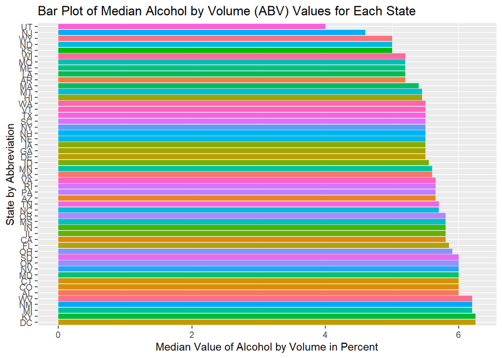

```r
################################### Question 4 ##################################

# this will return medians for each state ( NA NOT INCLUDED )
state_medians <- beer_brew %>% group_by(State) %>%
  summarise(num_brew = n_distinct(Brew_name),
            median_abv = median(ABV, na.rm = TRUE), median_ibu = median(IBU, na.rm = TRUE)) %>%
  arrange(desc(num_brew))

# to return the medians data
# state_medians

# convert to data frame
state_medians <- as.data.frame(state_medians)

# convert variable column from S to s (upper to lower) so that it works with data in next question
names(state_medians)[1] <- 'state'

# plot Median ABV
state_medians %>% ggplot(aes(x = reorder(state, desc(median_abv)), y = median_abv*100, fill = state))+
  geom_bar(stat='identity', show.legend = FALSE)+
  coord_flip() +
  ggtitle("Bar Plot of Median Alcohol by Volume (ABV) Values for Each State") +
  xlab("State by Abbreviation")+
  ylab("Median Value of Alcohol by Volume in Percent")
```

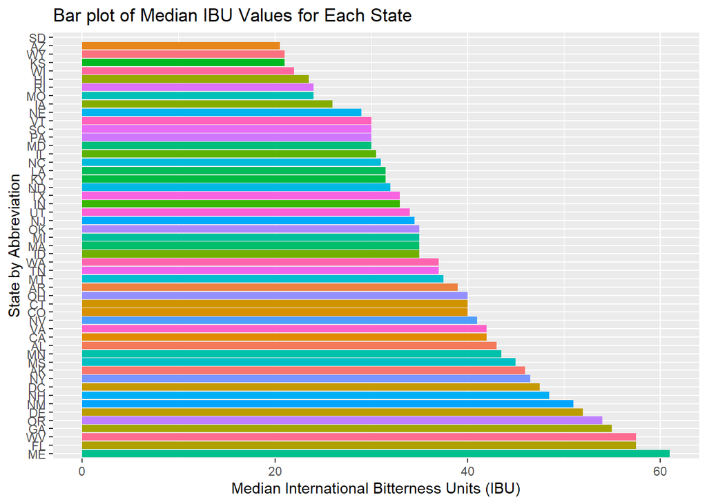

```r
# plot Median IBU
state_medians %>% ggplot(aes(x = reorder(state, desc(median_ibu)), y = median_ibu, fill = state))+
  geom_bar(stat = 'identity', show.legend = FALSE) +
  coord_flip() +
  ggtitle("Bar plot of Median IBU Values for Each State")+
  xlab("State by Abbreviation")+
  ylab("Median International Bitterness Units (IBU)")
```

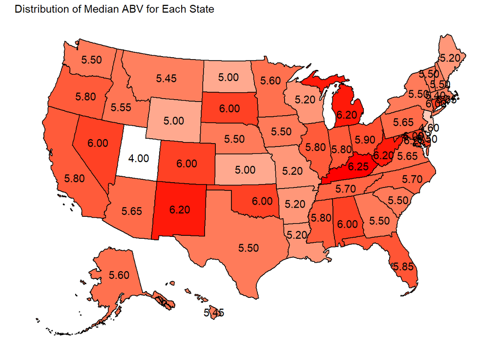

```r
# creating a variable to call for median labels
median_labels <- merge(centroid_labels, state_medians, by ='state')

# create the ABV map
abv_state_plot <- plot_usmap(data = state_medians[,1:3],
                             values = "median_abv",
                             color = "black",
                             labels = F) +
  guides(fill = "none") +
  geom_text(data = median_labels, aes(
    x = x, y = y,
    label = scales::number(median_abv * 100, accuracy = 0.01)), color = "black") +
  scale_fill_gradient(low = "white", high = "red") +
  labs(title = "Distribution of Median ABV for Each State")

# create the IBU map
ibu_state_plot <- plot_usmap(data = state_medians[,1:4],
                             values = "median_ibu",
                             color = "black",
                             labels = F)+
  guides(fill = "none")+
  geom_text(data = median_labels, aes(
    x = x, y = y,
    label = scales::number(median_ibu, accuracy = 1)), color = "black") +
  scale_fill_gradient(low = "white", high = "red")+
  labs(title = "Distribution of Median IBU for Each State")

# plot the ABV Median state plot
abv_state_plot
```

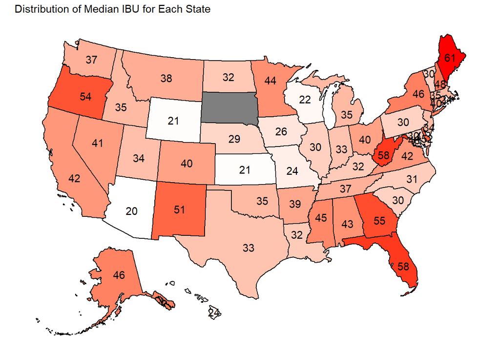

```r
# plot the IBU Median state plot
ibu_state_plot
```

## Question of Interest 5:

#### Determine Which States Contain the Highest Value of Alcohol by Volume (ABV) and International Bitterness Units (IBU).

The State with the highest International Bitterness Unit is Oregon (OR) at 138 IBUs. This value was determined by selecting only the State and IBU columns then running a function which would interpret the Max value.

```r
################################### Question 5 ##################################

# to call on selected data that will only return the sought after information
max_abv <- beer_brew %>% select(ABV, State)

max_abv[which.max(max_abv$ABV),]
```

```
      ABV State
369 0.128    CO
```

```r
# mean(max_abv$ABV, na.rm = TRUE) * 100 # 5.99 %
# median(max_abv$ABV, na.rm = TRUE) * 100 # 5.7 %
# plot for IBU
max_ibu <- beer_brew %>% select(IBU, State)

max_ibu[which.max(max_ibu$IBU),]
```

```
     IBU State
1771 138    OR
```

```r
# mean(max_ibu$IBU, na.rm = TRUE) # 42.955
# median(max_ibu$IBU, na.rm = TRUE) # 35
```

## Question of Interest 6:

#### Comment on the Summary Statistics & Distribution of The Alcohol by Volume (ABV) Variable

The Distribution of Alcohol by Volume across the United States appears to have a right skew to the data. This right skew can be interpreted as a distribution of data in which there tends to be a higher instance of larger values to the right of the median in the data, as opposed to an equal portion of large and small values to the right and left of the mean. A visual representation of this can be viewed below.

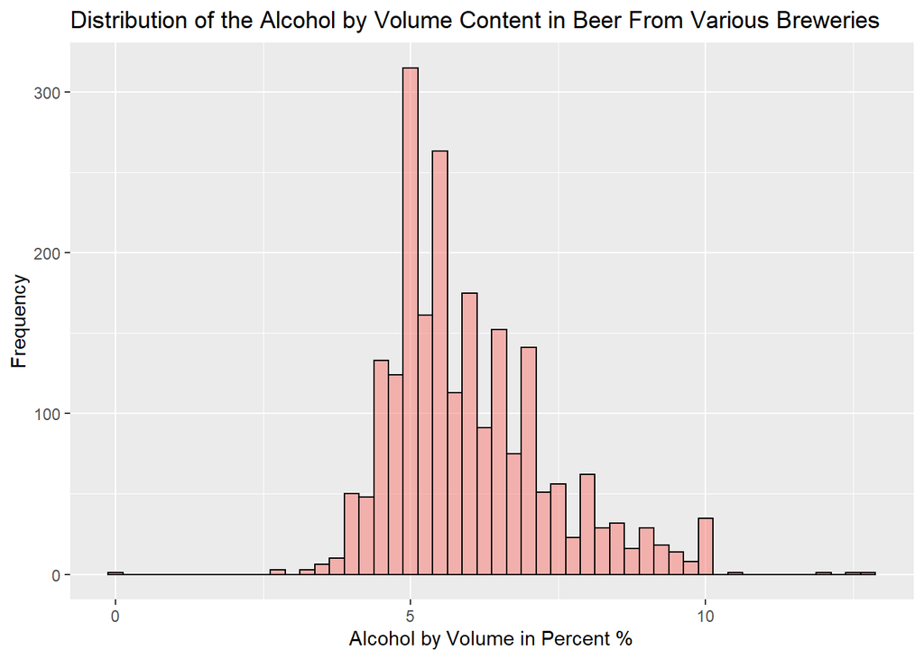

```r
################################### Question 6 ##################################

abv_dis_plot <- beer_brew %>% select(ABV,Brewery_id)
abv_dis_plot %>% ggplot(aes(ABV * 100)) +
  geom_histogram(color = 'black',aes(fill = 'red'), binwidth = .25, alpha = .5, show.legend = FALSE) +
  ggtitle('Distribution of the Alcohol by Volume Content in Beer From Various Breweries')+
  ylab('Frequency') + xlab('Alcohol by Volume in Percent %')
```

```r
summary(beer_brew$ABV * 100)
```

```
   Min. 1st Qu.  Median    Mean 3rd Qu.    Max.    NA's
  0.100   5.000   5.700   5.993   6.800  12.800      60
```

## Question of Interest 7:

#### Is there an apparent relationship between the bitterness of the beer and its alcoholic content?

It appears that there is a positive relationship between the bitterness of beer and its alcoholic content. We can visualize on a scatter plot that as the bitterness rating increases there tends to be an increase in Alcohol by Volume Percentage (ABV).

We created a series of scatter plots that would help clean up the visualization of the relationship between IBU and ABV as they relate to different styles. These plots are below:

### 1. First this plot shows us the general relationship with all styles included.

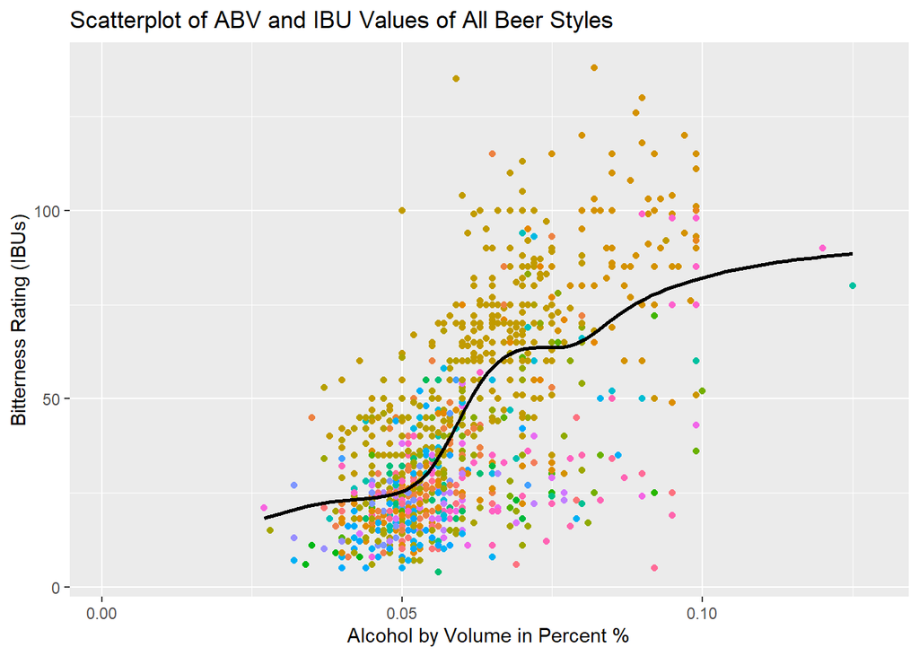

```r
################################### Question 7 ##################################

ibu_abv_plot <- beer_brew %>% select(IBU,ABV,Style)

ibu_abv_plot %>% ggplot(aes(x = ABV, y = IBU)) +
  geom_point(aes(color = Style), show.legend = FALSE) +
  geom_smooth(se = FALSE, color = "black") +
  ggtitle("Scatterplot of ABV and IBU Values of All Beer Styles") +
  xlab("Alcohol by Volume in Percent %") +
  ylab("Bitterness Rating (IBUs)")
```

### 2. This visualization is the same but filtered for only IPA beverages.

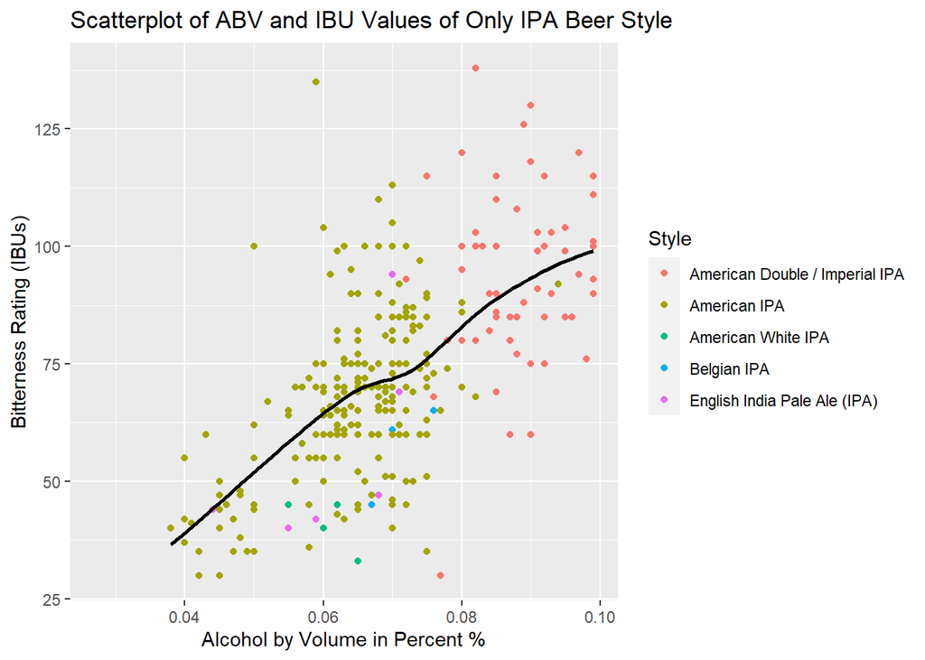

```r
# visualizing scatter plot of ABV and IBU with Style filter for all IPA
ipa_viz <- ibu_abv_plot %>% filter(str_detect(Style, 'IPA'))

ipa_viz %>% ggplot(aes(x = ABV, y = IBU)) +
  geom_point(aes(color = Style))+
  geom_smooth(se = FALSE, color = 'black') +
  ggtitle("Scatterplot of ABV and IBU Values of Only IPA Beer Style") +
  xlab("Alcohol by Volume in Percent %") +
  ylab("Bitterness Rating (IBUs)")
```

### 3. Below you will see a scatter plot filtered to visualize the same ABV, IBU relationship with only Ale beverages.

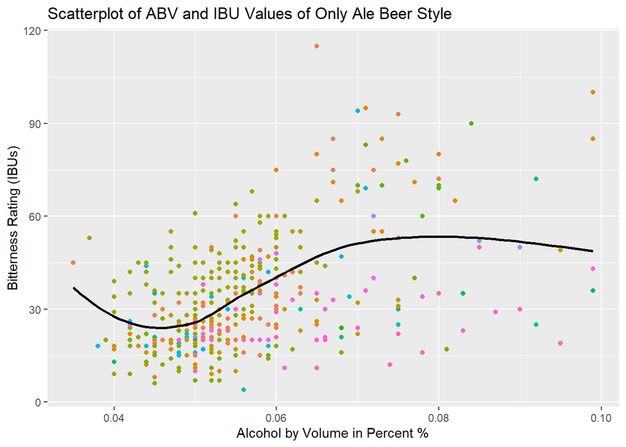

```r
# visualizing scatter plot of ABV and IBU with Style filter for all ALE
ale_viz <- ibu_abv_plot %>% filter(str_detect(Style, "Ale"))

ale_viz %>% ggplot(aes(x = ABV, y = IBU)) +
  geom_point(aes( color = Style), show.legend = FALSE) +
  geom_smooth(se = FALSE, color = 'black') +
  ggtitle("Scatterplot of ABV and IBU Values of Only Ale Beer Style") +
  xlab("Alcohol by Volume in Percent %") +
  ylab("Bitterness Rating (IBUs)")
```

### 4. Finally this scatter plot displays the ABV, IBU relationship with styles filterd to include every type that is NOT IPA, or Ale.

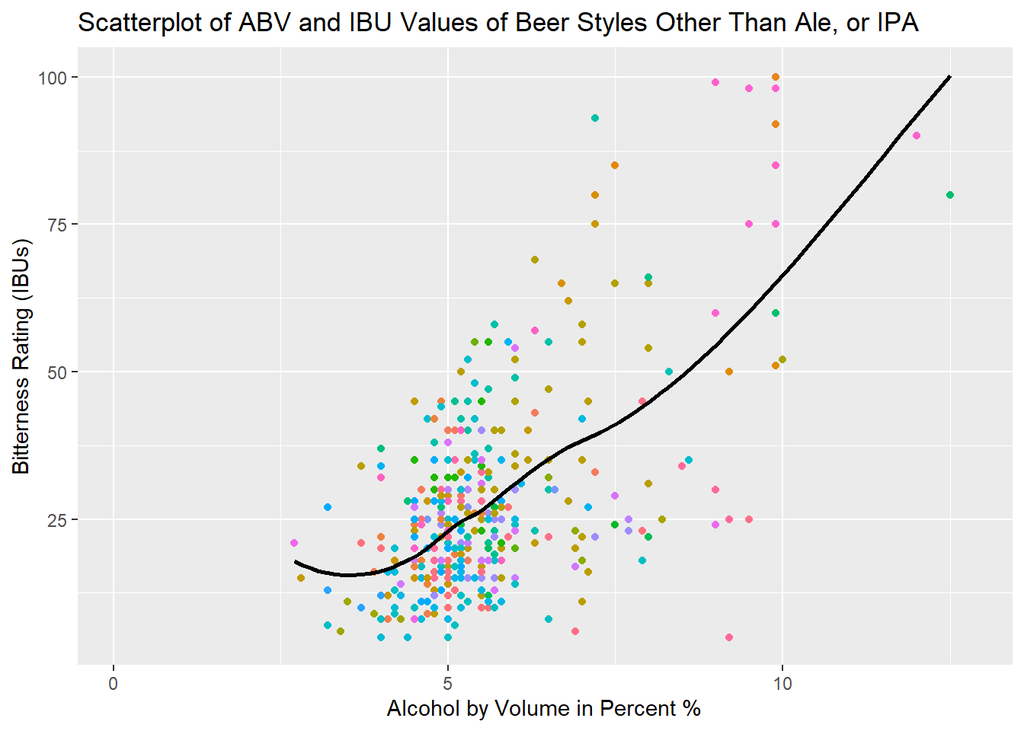

```r
# visualizing scatter plot of ABV and IBU with style filter for not ALE, or IPA
else_viz <- ibu_abv_plot %>% filter(!str_detect(Style, "Ale")) %>% filter(!str_detect(Style, "IPA"))

else_viz %>% ggplot(aes(x = ABV * 100, y = IBU)) +
  geom_point(aes(color = Style), show.legend = FALSE) +
  geom_smooth(se = FALSE, color = "black") +
  ggtitle("Scatterplot of ABV and IBU Values of Beer Styles Other Than Ale, or IPA") + xlab("Alcohol by Volume in Percent %")+ylab("Bitterness Rating (IBUs)")
```

#### It appears that across most styles of beer there is a positive relationship between IBU and ABV. It is worth discussing however the “Ale” style of beer has somewhat of a curved arguably non-linear relationship. The majority of values in which ABV is greater than 6% appear to be of an equal distribution about the y-axis, and lose their visual power to explain the variance of IBU ratings.

## Question of Interest 8:

#### Investigate the difference with respect to IBU and ABV between IPAs and other types of Ale.

We found with our model that it is possible to predict whether a beer is considered an IPA or Ale based on its IBU and ABV values at an Accuracy of 99.66102%. The model created to do this is a KNN model which uses neighboring values of a “k” amount around the given input to predict what the classification of the item in question is.

```r
################################### KNN Prediction Model Data #########################

# test to see how the model will work using beer_brew

# make a Dataframe without NA so that we can run KNN:
beer_predict <- na.omit(beer_brew)
# sanity check
#view(beer_predict)

ipa_knn_2 <- beer_predict %>% select(Brewery_id,beer_name, IBU, ABV, Style) %>%
  group_by(Brewery_id) %>% filter(between(IBU, 55, 100)) %>%
  mutate(Style = "ipa")

ale_knn_3 <- beer_predict %>% select(Brewery_id,beer_name, IBU, ABV, Style) %>%
  group_by(Brewery_id) %>% filter(str_detect(Style, "Ale")) %>% filter(!between(IBU, 55, 100)) %>%
  mutate(Style = "ale")

combine_knn_2 <- full_join(ipa_knn_2, ale_knn_3)
set.seed(765)
intrain <- sample(nrow(combine_knn_2), round(nrow(combine_knn_2)*.30))
beer_train <- combine_knn_2[intrain,]
beer_test <- combine_knn_2[-intrain,]


# setting up the classification
classification <- knn(beer_train[,c(3,4)],
                      beer_test[,c(3,4)],
                      beer_train$Style,
                      k = 3, prob = TRUE)

# setting up a passable data for confusion matrix
u <- union(classification, beer_test$Style)
t <- table(factor(classification, u), factor(beer_test$Style, u), dnn = c("Prediction", "Truth"))

# confusion matrix for more stats on the model
CM <- confusionMatrix(t)

cat('Accuracy:',CM$overall[1]*100,"%",
    "\nSensitivity:",CM$byClass[1]*100, "%",
    "\nSpecificity:",CM$byClass[2]*100, "%")
```

```
## Accuracy: 99.66102 %
## Sensitivity: 100 %
## Specificity: 99.35275 %
```

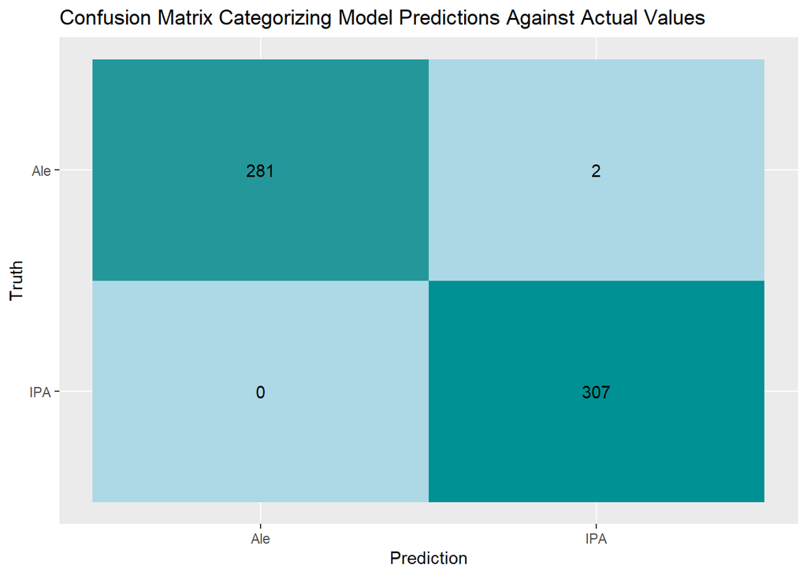

```r
beer_knn_plot <- as.data.frame(CM$table)

beer_knn_plot$Prediction <- factor(beer_knn_plot$Prediction, levels = rev(levels(beer_knn_plot$Truth)))

ggplot(beer_knn_plot, aes(Prediction, Truth, fill = (Freq))) +
  geom_tile(show.legend = FALSE) + geom_text(aes(label = (Freq))) +
  scale_fill_gradient(low = "light blue", high = "#009194") +
  labs(x = "Truth", y = "Prediction") +
  scale_x_discrete(labels = c("IPA", "Ale")) +
  scale_y_discrete(labels = c("Ale", "IPA"))+
  coord_flip()+
  ggtitle("Confusion Matrix Categorizing Model Predictions Against Actual Values")
```

#### Key model Statistics:

Accuracy 99.66102% - Overall Accuracy of the classifier.

Sensitivity: 100% - (true positive rate) refers to the probability of a positive test, conditioned on truly being positive.

Specificity: 99.35275% - (true negative rate) refers to the probability of a negative test, conditioned on truly being negative.

## Question of Interest 9-A

#### Report Any Additional Findings

Because Booze and Brews is looking to enter the US Brewery market, we thought it would be insightful to visualize data that would provide insight into the style of brew which hold the greatest (or least) market share. The data show us that 73.53% of the brew offerings are of a non-IPA style beverage. This poses an interesting questions such as:

1. Is the current saturation of IPA high or low compared to consumer demand?
2. What is the significance of IPAs in terms of sale numbers as a percentage of goods sold?
3. Does the relative low percentage of IPA representation mean there is an opportunity to enter the market with IPA? Or does it simply speak to the demand of the IPA offerings?

These questions serve as an opportunity to gather a new perspective of data that can provide invaluable insights into the brewery market and some of the demand currently within the market.

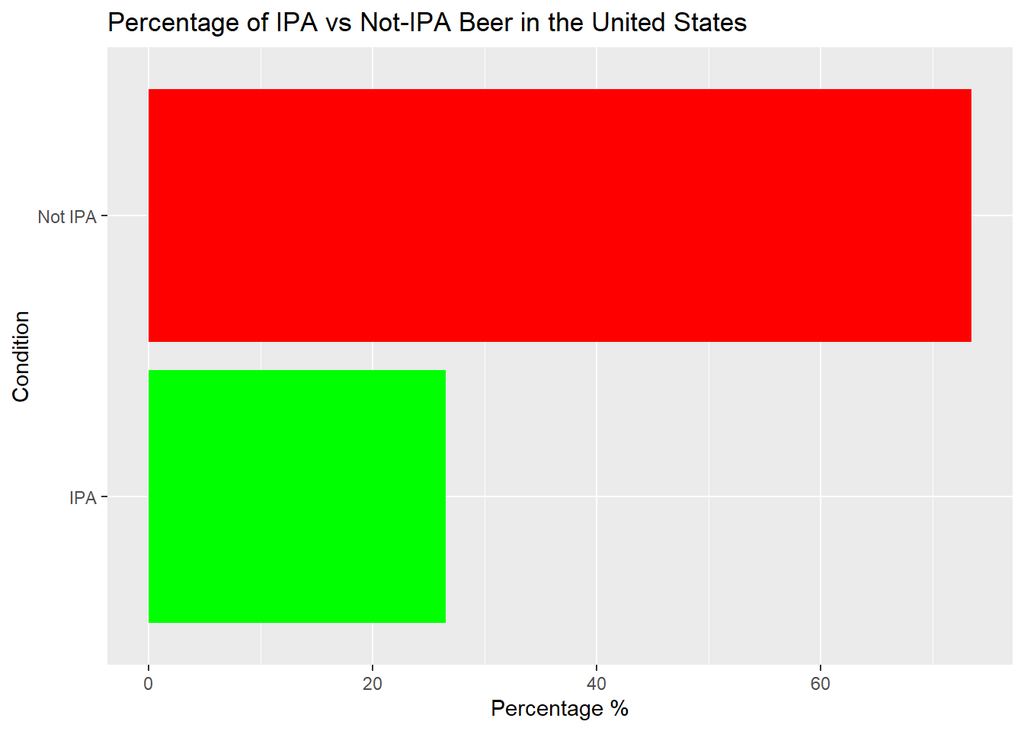

```r
beer_predict$IsIPA = ifelse(beer_predict$IBU > 55 & beer_predict$IBU < 100, "IPA", "Not IPA")
beer_predict %>%
  group_by(IsIPA) %>%
  dplyr::summarize(count=n()) %>%
  mutate(percent = (count/sum(count))*100) %>%
  ggplot() +
  geom_bar(aes(y=percent, x = IsIPA, fill = IsIPA),show.legend = FALSE, stat="identity") +
  scale_fill_manual(values=c("green","red")) +
  coord_flip() +
  ggtitle("Percentage of IPA vs Not-IPA Beer in the United States")+
  xlab('Condition')+
  ylab('Percentage %')
```

## Question of Interest 9-B

#### Report Any Additional Findings

Because Booze and Brews is looking to capture Texas market share, we thought it would be insightful to visualize data that would give insight into the distribution of the type of styling characteristic (IBU, ABV) across Cities in Texas. The Data shows us that the median IBU for Texas is 33, and the median ABV for Texas is 5.5%. This information along with the visualizations below provide us with insights that illustrate which of the stylistic profiles are prominent in these geographical areas.

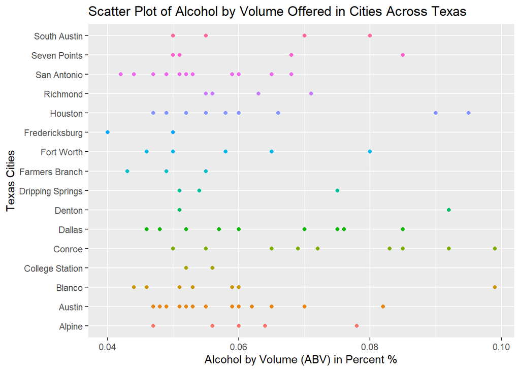

```r
extra_data <- beer_brew %>% select(City, State, IBU, ABV, Style, Ounces) %>% filter(State == "TX")

# Scatter plot for ABV for each city in Texas
beer_brew %>% select(City, State, IBU, ABV, Style, Ounces) %>% filter(State == "TX") %>%
  ggplot(aes(City, ABV, color = City))+
  geom_point(show.legend = FALSE) +
  coord_flip()+
  ggtitle("Scatter Plot of Alcohol by Volume Offered in Cities Across Texas") +
  ylab('Alcohol by Volume (ABV) in Percent %') +
  xlab('Texas Cities')
```

#### Here we can see how various ABV values appear within different cities in Texas. Additionally we can see from the scatter plot how the value between 4% - 6% seem to contain the more populated instances compared to above 6%. Below we will see a simiar pattern in the distribution of ABV values for Texas illustrated by a Histogram.

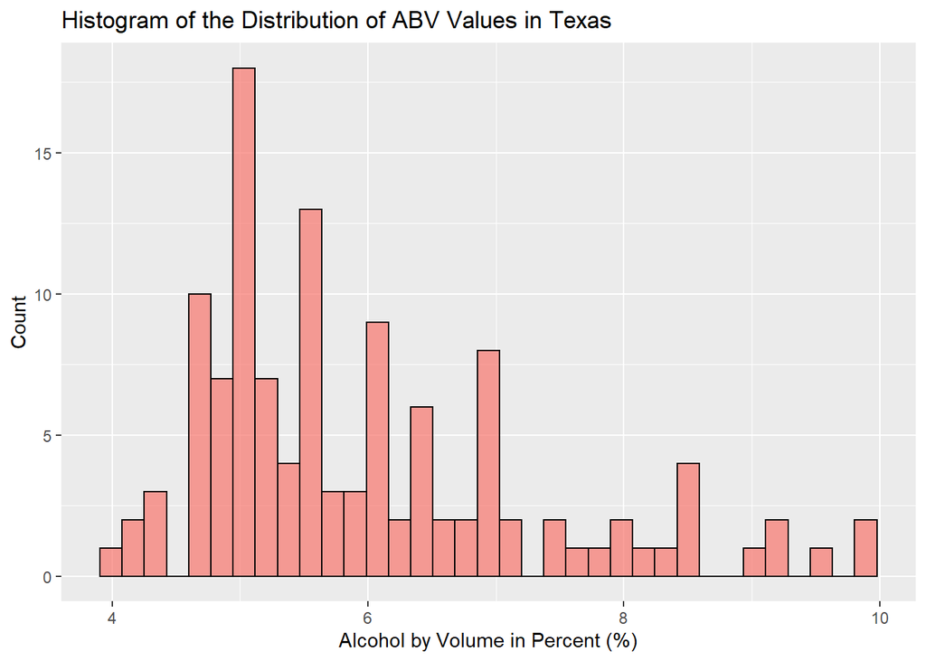

```r
# histogram for distribution of ABV in Texas
extra_data %>% ggplot(aes(ABV*100)) +
  geom_histogram(aes(fill = 'red'),show.legend = FALSE,bins = 35, color = 'black', alpha = .7)+
  ggtitle('Histogram of the Distribution of ABV Values in Texas') +
  xlab("Alcohol by Volume in Percent (%)")+
  ylab("Count")
```

#### In the Scatter plot below we can see how various IBU values appear within different cities in Texas. Additionally we can see from the scatter plot how the value between 23-55 seem to contain the more populated instances compared to above 60 where it becomes very seldom to see occurances.

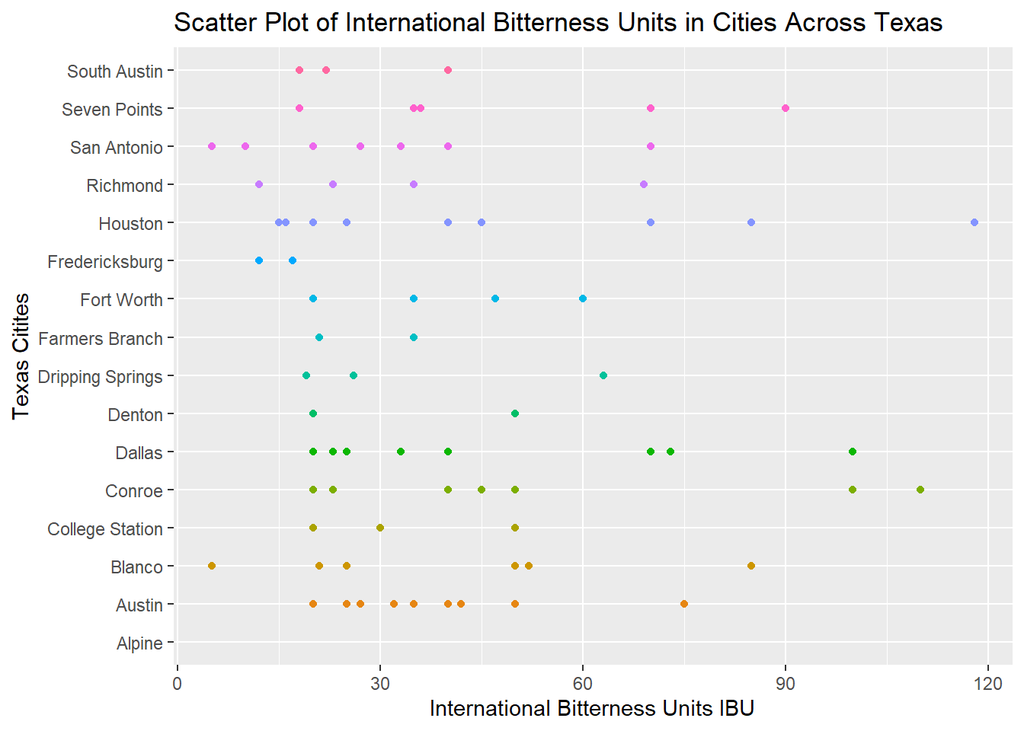

```r
# Scatter plot for the IBU for each city in TEXAS
beer_brew %>% select(City, State, IBU, ABV, Style, Ounces) %>% filter( State == "TX") %>%
  ggplot(aes(City, IBU, color = City)) +
  geom_point(show.legend = FALSE) +
  coord_flip()+
  ggtitle("Scatter Plot of International Bitterness Units in Cities Across Texas") +
  ylab("International Bitterness Units IBU") +
  xlab("Texas Citites")
```

#### Below we can visually see the same pattern represented in the IBU scatterplot in this IBU Histogram distribution for Texas values of IBU.

[figure not shown]

```r
# histogram for distribution of IBU in Texas
extra_data %>% ggplot(aes(IBU))+
  geom_histogram(aes(fill = 'red'),show.legend = FALSE,bins = 35, color = 'black', alpha = .7)+
  ggtitle("Histogram of the Distribution of ABV Values in Texas")+
  xlab("International Bitterness Units (IBUs)")+
  ylab('Count')
```

#### Finally, to provide just a bit of actionable insight, the scatter plot below shows the instances of various styles in Texas Cities. To make this a more insightful plot futher research will be required along with a more specific approach on gathering data to make a meaningful inference. For now we can say that visually there appears to be a relatively stronger occurance of various American Ale style beverages offered in Texas Cities.

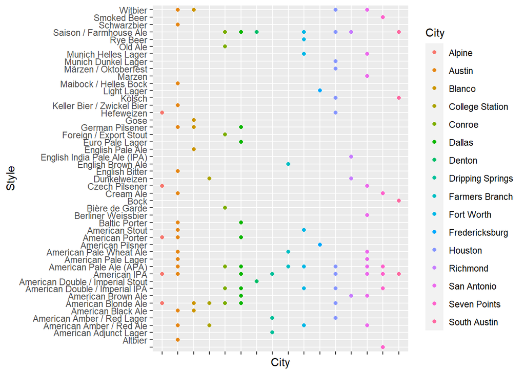

```r
extra_data %>% ggplot(aes(Style, City))+
  geom_point(aes(color = City))+
  coord_flip()+
  theme(axis.text.x = element_blank())
```

```r
#summary(na.omit(extra_data$IBU))
#summary(na.omit(extra_data$ABV)*100)
```

## Conclusion:

9. Finally, Because Booze and Brews is looking to capture Texas market share, we thought it would be insightful to visualize data that would give insight into the distribution of the type of styling characteristic (IBU, ABV) across Cities in Texas. The Data shows us that the median IBU for Texas is 33, and the median ABV for Texas is 5.5%. This information along with the visualizations below provide us with insights that illustrate which of the stylistic profiles are prominent in these geographical areas. We have visual evidence that there does seem to exist a specific flavor profile that Texans prefer, and investigating this further could prove to assist in establishing a successful brewery with offerings that appeal to the palete of the target audience.

Thank you for the opportunity to work with your company. We warmly welcome any questions, and hope that this data can inspire new questions about the Brewery market that will spark the next step in understanding the optimal business plan for your success.

Robert Blue | robert.blue@smu.edu Joey Hernandez | joeyhernandez@smu.edu